# HW3

# HW2

## github: https://github.com/madojames/STATS506/tree/main

## Q1

### a

```r
library(haven)
library(tidyverse)
# read XPT data
VIX_D <- read_xpt("VIX_D.xpt")
DEMO_D <- read_xpt("DEMO_D.xpt")

#merge them together
merged_df <- merge(VIX_D, DEMO_D, by = "SEQN")
sample_size <- nrow(merged_df)
print(sample_size)
```

```
[1] 6980
```

So from the result of the size we know we successfully merge the two data together

### b

```r
#print(head(merged_df))
library(knitr)

#transfer 1,2 to 1 and NA to 0 to mark wear or not wear
merged_df$VIQ220[merged_df$VIQ220 == 9] <- NA
merged_df$VIQ220 <- merged_df$VIQ220 - 1

#compute the proportion wear/all_num(without NA)
age_brackets <- cut(merged_df$RIDAGEYR, breaks = seq(0, 90, by = 10), right = FALSE)
results <- merged_df %>%
  group_by(age_bracket = age_brackets) %>%
  summarise(
    total_respondents = sum(!is.na(VIQ220)),
    glasses_count = sum(VIQ220, na.rm = TRUE),
    proportion = round(glasses_count / total_respondents, 3)
  )

results_table <- results %>%
  select(age_bracket, total_respondents, glasses_count, proportion)

#plot with kable
kable(results_table, format = "html", caption = "Proportion of Respondents Wearing Glasses/Contact Lenses", digits = 3)
```

Proportion of Respondents Wearing Glasses/Contact Lenses

| age_bracket | total_respondents | glasses_count | proportion |
| --- | --- | --- | --- |
| [10,20) | 2088 | 1418 | 0.679 |
| [20,30) | 937 | 631 | 0.673 |
| [30,40) | 750 | 481 | 0.641 |
| [40,50) | 773 | 487 | 0.630 |
| [50,60) | 609 | 274 | 0.450 |
| [60,70) | 630 | 238 | 0.378 |
| [70,80) | 447 | 148 | 0.331 |
| [80,90) | 311 | 103 | 0.331 |

### c

```r
library(broom)

#rename the col
colnames(merged_df)[colnames(merged_df) == "RIDAGEYR"] <- "age"
colnames(merged_df)[colnames(merged_df) == "RIAGENDR"] <- "gender"
colnames(merged_df)[colnames(merged_df) == "RIDRETH1"] <- "race"
colnames(merged_df)[colnames(merged_df) == "INDFMPIR"] <- "PIR"

#make the gender and race as factor
merged_df$gender <- factor(merged_df$gender,
                  levels = 1:2,
                  labels = c("Male",
                             "Female"))

merged_df$race <- factor(merged_df$race,
                  levels = 1:5,
                  labels = c("Mexican American",
                             "Other Hispanic",
                             "Non-Hispanic White",
                             "Non-Hispanic Black",
                             "Multi-racial"))
```

```r
#fit the model
lrm1 <- glm(VIQ220 ~ age, data = merged_df, family = binomial)
lrm2 <- glm(VIQ220 ~ age + gender + race, data = merged_df, family = binomial)
lrm3 <- glm(VIQ220 ~ age + gender + race + PIR, data = merged_df, family = binomial)


# compute odds ratios
model1_odds_ratios <- exp(coef(lrm1))
model2_odds_ratios <- exp(coef(lrm2))
model3_odds_ratios <- exp(coef(lrm3))

# create table
odds_ratios_table <- data.frame(
  Model1 = c(model1_odds_ratios, rep(NA,6)),  # 添加 NA 以对齐长度
  Model2 = c(model2_odds_ratios, NA),
  Model3 = c(model3_odds_ratios)
)

#create row for Sample_Size, AIC, Pseudo_R2
Sample_Size <- data.frame( Model1=nobs(lrm1),Model2=nobs(lrm2),Model3=nobs(lrm3),row.names="Sample_Size")
AIC <- data.frame( Model1=AIC(lrm1),Model2=AIC(lrm2),Model3=AIC(lrm3),row.names="AIC")
Pseudo_R2 <- data.frame(Model1=(1 - (lrm1$deviance / lrm1$null.deviance)), Model2=(1 - (lrm2$deviance / lrm2$null.deviance)), Model3=(1 - (lrm3$deviance / lrm3$null.deviance)),row.names="Pseudo_R2")

#add to the df
odds_ratios_table <- rbind(odds_ratios_table, Sample_Size, AIC, Pseudo_R2)

#format
odds_ratios_table <- odds_ratios_table %>%
  mutate(across(starts_with("Model"), round, 4)) %>%
  kable(caption = "Odds Ratios for Each Model")
odds_ratios_table
```

Odds Ratios for Each Model

|  | Model1 | Model2 | Model3 |
| --- | --- | --- | --- |
| (Intercept) | 3.5288 | 6.2756 | 7.5094 |
| age | 0.9756 | 0.9777 | 0.9781 |
| genderFemale | NA | 0.6053 | 0.5967 |
| raceOther Hispanic | NA | 0.8553 | 0.8905 |
| raceNon-Hispanic White | NA | 0.5123 | 0.6056 |
| raceNon-Hispanic Black | NA | 0.7696 | 0.8127 |
| raceMulti-racial | NA | 0.5215 | 0.5870 |
|  | NA | NA | 0.8926 |
| Sample_Size | 6545.0000 | 6545.0000 | 6247.0000 |
| AIC | 8475.8866 | 8287.7609 | 7909.8082 |
| Pseudo_R2 | 0.0497 | 0.0720 | 0.0734 |

### d

```r
summary(lrm3)
```

```
Call:
glm(formula = VIQ220 ~ age + gender + race + PIR, family = binomial,
    data = merged_df)

Coefficients:
                        Estimate Std. Error z value Pr(>|z|)
(Intercept)             2.016160   0.087788  22.966  < 2e-16 ***
age                    -0.022188   0.001295 -17.135  < 2e-16 ***
genderFemale           -0.516271   0.054305  -9.507  < 2e-16 ***
raceOther Hispanic     -0.116023   0.168265  -0.690 0.490495
raceNon-Hispanic White -0.501529   0.075149  -6.674 2.49e-11 ***
raceNon-Hispanic Black -0.207385   0.079217  -2.618 0.008847 **
raceMulti-racial       -0.532727   0.140152  -3.801 0.000144 ***
PIR                    -0.113598   0.017707  -6.415 1.41e-10 ***
---
Signif. codes:  0 '***' 0.001 '**' 0.01 '*' 0.05 '.' 0.1 ' ' 1

(Dispersion parameter for binomial family taken to be 1)

    Null deviance: 8519.1  on 6246  degrees of freedom
Residual deviance: 7893.8  on 6239  degrees of freedom
  (733 observations deleted due to missingness)
AIC: 7909.8

Number of Fisher Scoring iterations: 4
```

```r
exp(coef(lrm3)["genderFemale"])
```

```
genderFemale
   0.5967415
```

```r
#ratio of man woman wearing glass
wearers_by_gender <- merged_df %>%
  group_by(gender) %>%
  summarise(
    total = sum(!is.na(VIQ220)),
    wearers = sum(VIQ220, na.rm = TRUE),
    proportion = mean(VIQ220, na.rm = TRUE)
  )

print(wearers_by_gender)
```

```
# A tibble: 2 × 4
  gender total wearers proportion
  <fct>  <int>   <dbl>      <dbl>
1 Male    3195    2014      0.630
2 Female  3350    1766      0.527
```

SO the model show that the female is significant with p value < 0.05. The odds ratio of the woman is 0.597 < 1 meaning that the female gender will decrease the possible of wearing glasess/contact lenses for distance vision. And from the proportion of wearing in two gender also support that gender matters. So the gender does influence whether a person wear glasess/contact lenses for distance vision or not.

## Q2

### a

```r
library(DBI)
sakila <- dbConnect(RSQLite::SQLite(), "sakila_master.db")

# print the names of table and col to better understand the data
# dbListTables(sakila)
# dbListFields(sakila, "film")

# SQl for film data
dbGetQuery(sakila, "
           SELECT release_year, COUNT(film_id) as count
            FROM film
            WHERE release_year = (SELECT MIN(release_year) FROM film)
            GROUP BY release_year;
           ")
```

```
  release_year count
1         2006  1000
```

The oldest movie is from 2006 and the total number of movies were released in 2006 iss 1000

### b

```r
#SQL + r cersion on genre of moive
#get the table
fc <- dbGetQuery(sakila, "SELECT * FROM film_category")
c <- dbGetQuery(sakila, "SELECT * FROM category")

# find the minimal count
count <- table(fc$category_id)
least_common <- which.min(count)

#print out the
print(c(c$name[c$category_id == least_common], as.numeric(count[least_common])))
```

```
[1] "Music" "51"
```

```r
# single SQL version
dbGetQuery(sakila, "
            SELECT c.name, COUNT(*) as count
            FROM category AS c
            RIGHT JOIN
             (SELECT f.film_id, fc.category_id
              FROM film AS f
              LEFT JOIN film_category AS fc on fc.film_id = f.film_id
             ) AS ffc on ffc.category_id = c.category_id
             GROUP BY c.name
             ORDER BY count
             LIMIT 1
           ")
```

```
   name count
1 Music    51
```

They have the same output and suggest the category of music is the least common film type with 51 num of films in total.

### c

```r
# SQL + r cersion on genre of moive
# get the table
customer <- dbGetQuery(sakila, "SELECT * FROM customer")
address <- dbGetQuery(sakila, "SELECT * FROM address")
city <- dbGetQuery(sakila, "SELECT * FROM city")
country <- dbGetQuery(sakila, "SELECT * FROM country")

# join the tables
customer_address <- inner_join(customer, address, by = "address_id")
customer_address_city <- inner_join(customer_address, city, by = "city_id")
customer_full <- inner_join(customer_address_city, country, by = "country_id")
customer_country <- customer_full %>%
  select(customer_id, country)

#use table to create a table for the country
count <- table(customer_country$country)
print(count[count==13])
```

```
Argentina   Nigeria
       13        13
```

```r
# single SQL version, joinging table from customer to address to city to country
dbGetQuery(sakila, "
            SELECT country
            FROM
              (SELECT country.country, COUNT(*) as count
              FROM country
              RIGHT JOIN
                (SELECT ca.customer_id, ca.city_id, city.country_id
                FROM city
                RIGHT JOIN
                 (SELECT c.customer_id, c.address_id, a.city_id
                  FROM customer AS c
                  LEFT JOIN address AS a on c.address_id = a.address_id
                 ) AS ca on ca.city_id = city.city_id
                ) AS cac on cac.country_id = country.country_id
                GROUP BY country.country_id
              )
            WHERE count = 13
           ")
```

```
    country
1 Argentina
2   Nigeria
```

They both achieve the same result. From the result we can see that the Argentina and Nigeria have exactly 13 country.

## Q3

### a

```r
#load the data
df <- read.csv("us-500.csv")
```

```r
#get the  logical vector of whether .com is in it
sum(grepl(".com", df$email))
```

```
[1] 367
```

```r
sum(grepl(".com", df$email))/nrow(df)
```

```
[1] 0.734
```

So we get 367 emails with “.com” TLD. And the percentage of they in the group is 0.734.

### b

```r
#ignore alphanumeric and @ .
non_alphanumeric <- grepl("[^a-zA-Z0-9@.]", df$email)

#print the proportion
mean(non_alphanumeric)
```

```
[1] 0.248
```

The proportion of have at least one non alphanumeric character in them is 0.248

### c

```r
#getting all the first 3 num from phone
num1 <- substr(df$phone1, 1, 3)
num2 <- substr(df$phone2, 1, 3)

# get the top 5
area <- table(c(num1,num2))
sort(area,decreasing = TRUE)[1:5]
```

```
973 212 215 410 201
 36  28  28  28  24
```

So we know the top 5 common area codes is 973 212 215 410 201 in all numbers.

### d

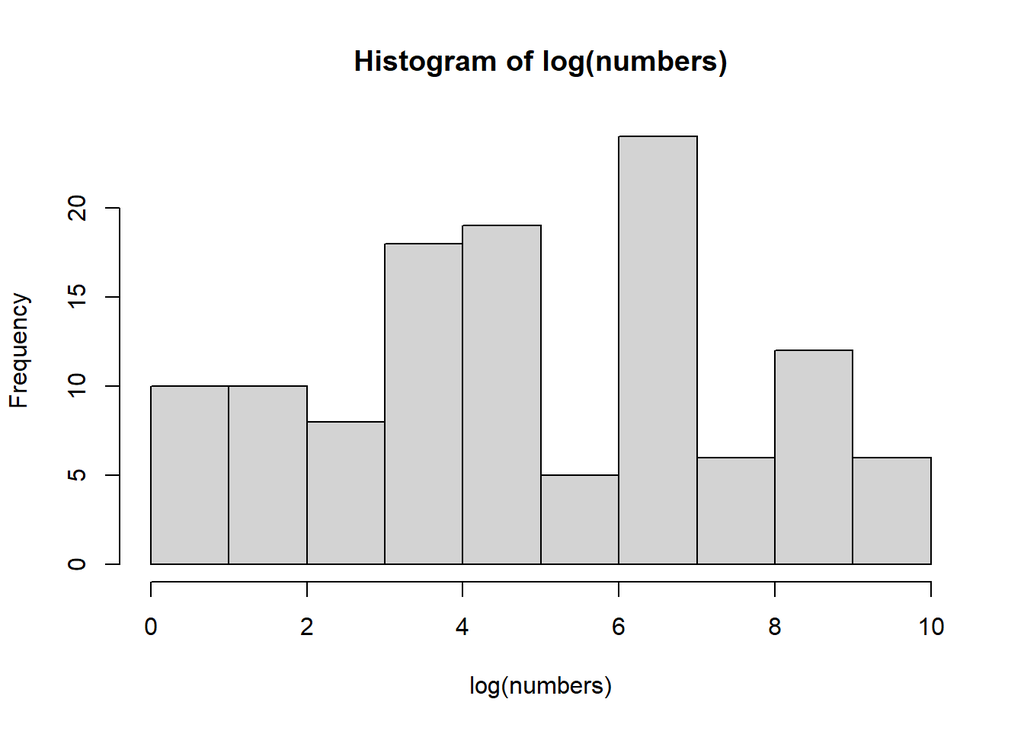

```r
#get all address end with num
address_num <- df$address[grepl("[0-9]$",df$address)]

#get all numbers out
numbers <- sub(".*[^0-9](\\d+)$", "\\1", address_num)
numbers <- as.numeric(numbers)

#plot the hist graph
hist(log(numbers))
```

### e

```r
#get all address end with num
address_num <- df$address[grepl("[0-9]$",df$address)]

# get the 1st number out
numbers <- sub(".*[^0-9](\\d+)$", "\\1", address_num)
num <- substr(numbers,1,1)

#show the distribution of the 1st num
table(num)
```

```
num
 1  2  3  4  5  6  7  8  9
15 13 12 12 15 11 12 11 17
```

So according to wiki, the Benford’s law is the decreasing trend of the probability of the 1st num. This distribution is clearly not decreasing so I consider it not pass as real data